# Feedback Viewing

Sydney Wood

## Libraries and Packages

```r
# Package names
packages <- c("ggplot2",  "tidyverse", "apaTables", "colourpicker", "swirl", "dplyr", "gridExtra", "knitr", "lme4", "reshape2", "stargazer",  "did", "plm", "sandwich", "coefplot", "afex", "jtools", "glmmTMB")



# Install packages not yet installed
installed_packages <- packages %in% rownames(installed.packages())
if (any(installed_packages == FALSE)) {
  install.packages(packages[!installed_packages])
}

# Packages loading
invisible(lapply(packages, library, character.only = TRUE))
```

[output not shown]

# Data cleaning

## exam files

done for each observation changing file names to correspond with file — not the most efficient

```
Time 1 = Exam 1 feedback views & Exam 1 written score
Time 2 = Exam 2 feedback views & Exam 2 written score
Time 3 = Exam 3 feedback views & Exam 3 written score
Time 4 = Exam 4 feedback views & Exam 4 written score
No time 5 since they don't recieve feedback before the end of the quarter
```

time1data <- read.csv(file = “1_A_Feb15.csv”)

time1data <- time1data %>% mutate(writtenScore = rowSums(across(14:31)))

time1data <- time1data %>% mutate(pwritten = writtenScore/120) time1data <- time1data %>% filter(!is.na(View.Count))

time1data <- time1data %>% select(“SID”, “Total.Score”, “View.Count”, “pwritten”) time1data <- time1data %>% mutate(time = 2)

write.csv(time1data, file = “time2D.csv”, row.names = FALSE)

## combining exams

data2A <- read.csv(file = “time2A.csv”)

data2B <- read.csv(file = “time2B.csv”)

data2C <- read.csv(file = “time2C.csv”)

data2D <- read.csv(file = “time2D.csv”)

data2 <- rbind(data2A, data2B, data2C, data2D)

write.csv(data2, file = “FeedbackTime2.csv”, row.names = FALSE)

## combining observations

data1 <- read.csv(“FeedbackTime1.csv”) data2 <- read.csv(“FeedbackTime2.csv”) data3 <- read.csv(“FeedbackTime3.csv”) data4 <- read.csv(“FeedbackTime4.csv”)

data <- rbind(data1, data2, data3, data4)

write.csv(data, file = “FeedbackFull.csv”, row.names = FALSE)

# Descriptives

## full data

```r
setwd("~/GitHub/MC_data_cleaning/2023 data/new version of exams")
desc <- read.csv(file = "2023_cleaned.csv")
```

```r
data <- read.csv("FeedbackFull.csv")

data$time <- as.factor(data$time)

data <- data %>% mutate(viewed = case_when(View.Count == 0 ~ 0, View.Count > 0 ~ 1, .default = View.Count))

data <- data %>% mutate(Total.Score= Total.Score/150 *100) %>% mutate(pwritten = pwritten*100) %>% filter(opt_in != "#N/A")

data$student_id <- as.factor(data$SID)
data$SID <- as.factor(data$SID)
data$opt_in <- as.factor(data$opt_in)
```

```r
fulldata <- read.csv("~/GitHub/MC_data_cleaning/2023 data/Final_Data.csv")

score_data <- fulldata %>% select(SID = Real_id, anon_id = student_id, opt_in, exam1:exam5, p_tot1:p_tot5)



score_data$SID <- as.factor(score_data$SID)
score_data$opt_in <- as.factor(score_data$opt_in)

data <- right_join(data, score_data, by = c("SID", "opt_in"))

data <- data %>% mutate(f_score = case_when(time == "1" ~ p_tot2, time == "2"~p_tot3, time == "3"~p_tot4, time == "4" ~ p_tot5))

data <- data %>% mutate(p_score = case_when(time == "1" ~ exam1, time == "2"~exam2, time == "3"~exam3, time == "4" ~ exam4))
```

# Descriptives

| pViewed | sdViewed |
| --- | --- |
| 0.7032967 | 0.4569616 |

unit <- c(“Exam 1”, “Exam 2”, “Exam 3”, “Exam 4”, “Exam 5”) mean <- c(mean(desc$p_tot1, na.rm = T), mean(desc$p_tot2, na.rm = T), mean(desc$p_tot3, na.rm = T), mean(desc$p_tot4, na.rm = T), mean(desc$p_tot5, na.rm = T)) sd <- c(sd(desc$p_tot1, na.rm = T), sd(desc$p_tot2, na.rm = T), sd(desc$p_tot3, na.rm = T), sd(desc$p_tot4, na.rm = T), sd(desc$p_tot5, na.rm = T)) median <- c(median(desc$p_tot1, na.rm = T), median(desc$p_tot2, na.rm = T), median(desc$p_tot3, na.rm = T), median(desc$p_tot4, na.rm = T), median(desc$p_tot5, na.rm = T)) MAD <- c(mad(desc$p_tot1, na.rm = T), mad(desc$p_tot2, na.rm = T), mad(desc$p_tot3, na.rm = T), mad(desc$p_tot4, na.rm = T), mad(desc$p_tot5, na.rm = T))

perf_descriptives <- cbind(unit, mean, sd, median, MAD)

# RQ 1 Analysis

Exam score –> views on that exam score and feedback are on the same exam

```r
rq1data <- data %>% select(p_score, viewed, time)
```

## Model 1

```r
lin <- "viewed~p_score + (1|time) "
rq1mod1 <- glmer(lin, rq1data, family = "binomial")

#?glm

summ(rq1mod1)
```

```
MODEL INFO:
Observations: 1456
Dependent Variable: viewed
Type: Mixed effects generalized linear regression
Error Distribution: binomial
Link function: logit

MODEL FIT:
AIC = 1700.23, BIC = 1716.08
Pseudo-R² (fixed effects) = 0.05
Pseudo-R² (total) = 0.08

FIXED EFFECTS:
------------------------------------------------
                     Est.   S.E.   z val.      p
----------------- ------- ------ -------- ------
(Intercept)         -1.74   0.39    -4.49   0.00
p_score              0.03   0.00     7.45   0.00
------------------------------------------------

RANDOM EFFECTS:
---------------------------------
 Group    Parameter    Std. Dev.
------- ------------- -----------
 time    (Intercept)     0.32
---------------------------------

Grouping variables:
-------------------------
 Group   # groups   ICC
------- ---------- ------
 time       4       0.03
-------------------------
```

```r
sum1 <- summary(rq1mod1)
sum1
```

```
Generalized linear mixed model fit by maximum likelihood (Laplace
  Approximation) [glmerMod]
 Family: binomial  ( logit )
Formula: viewed ~ p_score + (1 | time)
   Data: rq1data

      AIC       BIC    logLik -2*log(L)  df.resid
   1700.2    1716.1    -847.1    1694.2      1453

Scaled residuals:
    Min      1Q  Median      3Q     Max
-2.6103 -1.0858  0.5219  0.6486  1.5420

Random effects:
 Groups Name        Variance Std.Dev.
 time   (Intercept) 0.09966  0.3157
Number of obs: 1456, groups:  time, 4

Fixed effects:
             Estimate Std. Error z value Pr(>|z|)
(Intercept) -1.739102   0.387354   -4.49 7.13e-06 ***
p_score      0.033070   0.004439    7.45 9.36e-14 ***
---
Signif. codes:  0 ‘***’ 0.001 ‘**’ 0.01 ‘*’ 0.05 ‘.’ 0.1 ‘ ’ 1

Correlation of Fixed Effects:
        (Intr)
p_score -0.900
```

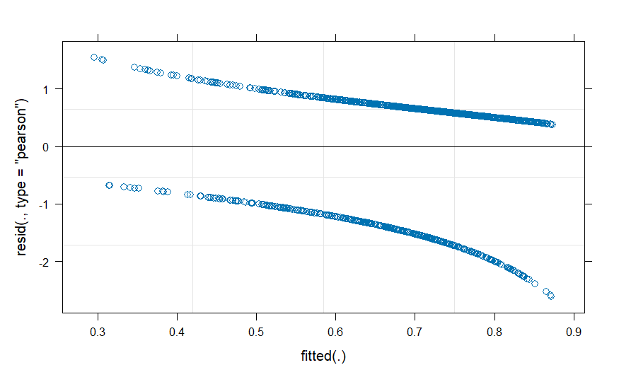

```r
rq1data$linfit <- predict(rq1mod1, rq1data)

rq1data$linprobs <- exp(rq1data$linfit)/(1+exp(rq1data$linfit))

plot(rq1mod1)
```

```r
NA
NA
NA
```

MODEL FIT: AIC = 1700.23, BIC = 1716.08 Pseudo-R² (fixed effects) = 0.05 Pseudo-R² (total) = 0.08 DF = 1453

Fit with maximum likelihood (Laplace Approximation)

```r
exp(o)/(1+exp(o))
```

```
[1] 0.827487
```

According to the linear model, a person with a hypothetical 0% score on the exam would have a 14.94% probability of viewing their exam feedback. The model also showed a significant positive linear relationship. Each point increase of written score is a .03 logit increase or 1.03 times the probability of viewing feedback. A student with a score of 1% would be expected to have 15.37% probability. A student with the score of 50% would be expected have q 47.86% probability and a student with a score of 100% would be expected to have a 82.75% probability of viewing their feedback.

Time ICC = .03 - 3% of the variance is due to differences across time quite small suggesting that time varying effects are likely insignificant.

## Model 2

```r
sum2
```

```
Generalized linear mixed model fit by maximum likelihood (Laplace
  Approximation) [glmerMod]
 Family: binomial  ( logit )
Formula: viewed ~ p_score + squared + (1 | time)
   Data: rq1data

      AIC       BIC    logLik -2*log(L)  df.resid
   1683.9    1705.0    -837.9    1675.9      1452

Scaled residuals:
    Min      1Q  Median      3Q     Max
-3.5055 -1.0345  0.4855  0.6788  1.0897

Random effects:
 Groups Name        Variance Std.Dev.
 time   (Intercept) 0.1065   0.3263
Number of obs: 1456, groups:  time, 4

Fixed effects:
            Estimate Std. Error z value Pr(>|z|)
(Intercept)  3.90172    1.40797   2.771 0.005586 **
p_score     -0.12906    0.03906  -3.304 0.000954 ***
squared      0.11184    0.02678   4.176 2.96e-05 ***
---
Signif. codes:  0 ‘***’ 0.001 ‘**’ 0.01 ‘*’ 0.05 ‘.’ 0.1 ‘ ’ 1

Correlation of Fixed Effects:
        (Intr) p_scor
p_score -0.983
squared  0.960 -0.993
```

MODEL FIT: AIC = 1683.87, BIC = 1705.00 Pseudo-R² (fixed effects) = 0.08 Pseudo-R² (total) = 0.11 DF = 1452

maximum likelihood (Laplace Approximation) [glmerMod]

```r
exp(o)/(1+exp(o))
```

```
[1] 0.8984297
```

This means that, while accounting for time varying effects, a student with a hypothetical score of 1% would have a 97.76% probability of viewing their exam, but a student with a 50% score would have an expected probability of 56.09 % and a student with 100% on the exam would be expected to have a 89.84% probability of viewing thier feedback.

Fits significantly better difference in X-square 18.361 p < .001

## Model 3 — failed to converge

```r
anova(rq1mod2, rq1mod3)
```

```
Data: rq1data
Models:
rq1mod2: viewed ~ p_score + squared + (1 | time)
rq1mod3: viewed ~ p_score + squared + cubed + (1 | time)
        npar    AIC    BIC  logLik -2*log(L)  Chisq Df Pr(>Chisq)
rq1mod2    4 1683.9 1705.0 -837.93    1675.9
rq1mod3    5 1683.8 1710.2 -836.90    1673.8 2.0659  1     0.1506
```

AIC = 1683.80, BIC = 1710.22 Pseudo-R² (fixed effects) = 0.08 Pseudo-R² (total) = 0.11

## plot

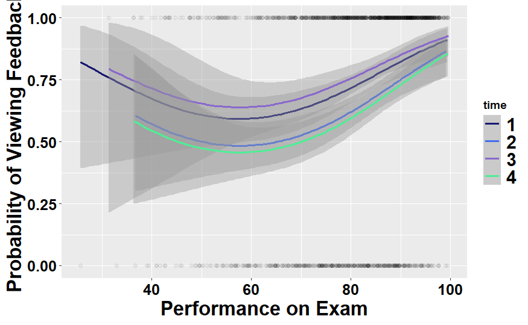

## Exploratory

```r
plot(erq1$grade, erq1$p_score)
```

[output not shown]

# RQ 2 Analyis

### Visualize Feedback Viewing

```r
colourPicker()
```

```
Listening on http://127.0.0.1:5937
```

```
[1] "#00B2EE" "#7EC0EE" "#40E0D0" "#66CDAA"
```

view = b0i * time1 + b1 * time2 + b2 * time3 + b4 * time4 + e

b0j = b0 + studenti

view = 1.81 + -.74 (if time2) + .58 (if time3) + -.76 (if time4) ### Model 1: Does Observation time predict Feedback Viewing?

```r
sum21
```

```
Generalized linear mixed model fit by maximum likelihood (Laplace
  Approximation) [glmerMod]
 Family: binomial  ( logit )
Formula: viewed ~ time + (1 | student_id)
   Data: data

      AIC       BIC    logLik -2*log(L)  df.resid
   1515.3    1541.7    -752.6    1505.3      1451

Scaled residuals:
    Min      1Q  Median      3Q     Max
-2.8338 -0.4284  0.2199  0.3432  1.7525

Random effects:
 Groups     Name        Variance Std.Dev.
 student_id (Intercept) 4.718    2.172
Number of obs: 1456, groups:  student_id, 370

Fixed effects:
            Estimate Std. Error z value Pr(>|z|)
(Intercept)   1.8103     0.2182   8.296  < 2e-16 ***
time2        -0.7414     0.2140  -3.465 0.000530 ***
time3         0.5820     0.2306   2.524 0.011611 *
time4        -0.7605     0.2143  -3.548 0.000387 ***
---
Signif. codes:  0 ‘***’ 0.001 ‘**’ 0.01 ‘*’ 0.05 ‘.’ 0.1 ‘ ’ 1

Correlation of Fixed Effects:
      (Intr) time2  time3
time2 -0.578
time3 -0.435  0.471
time4 -0.577  0.548  0.470
```

```r
exp(o)/(1+exp(o))
```

```
[1] 0.7407413
```

maximum likelihood (Laplace Approximation) [glmerMod]

Time 1 is between exam 1 & 2 Time 2 is Between 2 & 3 Time 3 is between 3 & 4 — intervention time period Time 4 is between 4 & 5 – post intervention lag 1

Pre-registered alpha of .01:

viewed = b0i*time1 + b1*optin + b2*time2 + b3*time3 + b4*time4 + b5*optin*time2 + b6*time3*optin + b7*time4*optin + e

b0i = b0 + studenti

### Model 2: Feedback viewing over time by intervention group

```r
summ(model2)
```

```
MODEL INFO:
Observations: 1456
Dependent Variable: viewed
Type: Mixed effects generalized linear regression
Error Distribution: binomial
Link function: logit

MODEL FIT:
AIC = 1473.51, BIC = 1521.06
Pseudo-R² (fixed effects) = 0.14
Pseudo-R² (total) = 0.62

FIXED EFFECTS:
--------------------------------------------------
                       Est.   S.E.   z val.      p
------------------- ------- ------ -------- ------
(Intercept)            1.28   0.27     4.67   0.00
opt_in1                0.90   0.39     2.33   0.02
time2                 -0.81   0.30    -2.73   0.01
time3                 -0.20   0.30    -0.66   0.51
time4                 -0.84   0.30    -2.82   0.00
opt_in1:time2          0.18   0.42     0.42   0.68
opt_in1:time3          2.05   0.51     4.02   0.00
opt_in1:time4          0.17   0.42     0.41   0.68
--------------------------------------------------

RANDOM EFFECTS:
--------------------------------------
   Group       Parameter    Std. Dev.
------------ ------------- -----------
 student_id   (Intercept)     2.05
--------------------------------------

Grouping variables:
------------------------------
   Group      # groups   ICC
------------ ---------- ------
 student_id     370      0.56
------------------------------
```

```r
exp(sum22$coefficients[1])/(1+exp(sum22$coefficients[1]))
```

[output not shown]

AIC = 1473.51, BIC = 1521.06 Pseudo-R² (fixed effects) = 0.14 Pseudo-R² (total) = 0.62

The only time that feedback viewing behavior significantly differed by group is between Exam 3 & 4 when the students who did the intervention were required to look at and correct thier feedback.

# RQ 3: Performance

## Descriptives

| time | variable | n | mean | sd | median | MAD | Q1 | Q3 | IQR | min | max |
| --- | --- | --- | --- | --- | --- | --- | --- | --- | --- | --- | --- |
| 1 | Subsequent Score | 362 | 73.41308 | 16.13529 | 76.47059 | 15.69812 | 63.97059 | 86.02941 | 22.05882 | 21.764706 | 98.52941 |
| 2 | Subsequent Score | 367 | 77.34506 | 14.39564 | 80.62500 | 14.36269 | 69.37500 | 88.12500 | 18.75000 | 26.562500 | 99.37500 |
| 3 | Subsequent Score | 362 | 78.71344 | 16.33078 | 83.52941 | 13.95388 | 69.11765 | 91.17647 | 22.05882 | 2.352941 | 100.00000 |
| 4 | Subsequent Score | 365 | 79.53212 | 13.87119 | 82.18750 | 13.43606 | 71.25000 | 90.00000 | 18.75000 | 20.937500 | 100.00000 |

## Model 1: Does feedback viewing on Exam X predict performance on Exam X+1?

```r
summary(m1)
```

```
Linear mixed model fit by REML. t-tests use Satterthwaite's method [
lmerModLmerTest]
Formula: eq1
   Data: data

REML criterion at convergence: 11347.9

Scaled residuals:
    Min      1Q  Median      3Q     Max
-6.5460 -0.4710  0.1209  0.5917  3.1713

Random effects:
 Groups     Name        Variance Std.Dev.
 student_id (Intercept) 116.589  10.798
 time       (Intercept)   8.089   2.844
 Residual               103.508  10.174
Number of obs: 1434, groups:  student_id, 370; time, 4

Fixed effects:
             Estimate Std. Error        df t value Pr(>|t|)
(Intercept)   74.1831     1.6536    5.1044  44.862 7.93e-08 ***
viewed         4.3048     0.8075 1400.3306   5.331 1.14e-07 ***
---
Signif. codes:  0 ‘***’ 0.001 ‘**’ 0.01 ‘*’ 0.05 ‘.’ 0.1 ‘ ’ 1

Correlation of Fixed Effects:
       (Intr)
viewed -0.344
```

REML. t-tests use Satterthwaite’s method [lmerModLmerTest]

## Is feedback viewing sufficient to serve as the mechanism that explains the changes in performance trajectories for the two groups before and after the intervention?

## Model 2

### Performance over time

```r
eq2 <- f_score ~ time + (1|student_id)

m2 <- lmer(eq2, data)

summ(m2)
```

[output not shown]

### Performance over time by feedback viewing

```r
summ(m3)
```

[output not shown]

### Performance over time by intervention and feedback viewing

```r
sum32
```

```
Linear mixed model fit by REML. t-tests use Satterthwaite's method [
lmerModLmerTest]
Formula: eq4
   Data: data

REML criterion at convergence: 11284.8

Scaled residuals:
    Min      1Q  Median      3Q     Max
-6.6232 -0.4806  0.1155  0.5917  3.2954

Random effects:
 Groups     Name        Variance Std.Dev.
 student_id (Intercept) 116.8    10.81
 Residual               103.3    10.16
Number of obs: 1434, groups:  student_id, 370

Fixed effects:
                       Estimate Std. Error         df t value Pr(>|t|)
(Intercept)            69.59277    1.69746 1374.71464  40.998  < 2e-16
time2                   5.28574    1.87685 1090.10503   2.816 0.004946
time3                   4.15473    1.96605 1098.14084   2.113 0.034806
time4                   6.20532    1.87534 1097.50298   3.309 0.000967
viewed                  5.90997    1.90477 1253.21989   3.103 0.001960
opt_in1                 0.23512    2.61202 1414.49167   0.090 0.928288
time2:opt_in1          -0.03077    2.96195 1098.66336  -0.010 0.991712
time3:opt_in1           2.83752    4.18757 1134.92282   0.678 0.498159
time4:opt_in1           2.44884    2.97653 1108.23727   0.823 0.410847
time2:viewed           -3.16669    2.40734 1106.24218  -1.315 0.188637
time3:viewed           -1.23095    2.47260 1117.30770  -0.498 0.618698
time4:viewed           -2.71119    2.44666 1123.08232  -1.108 0.268048
viewed:opt_in1         -1.90566    2.82886 1217.39821  -0.674 0.500661
time2:viewed:opt_in1    3.26331    3.59460 1114.03269   0.908 0.364161
time3:viewed:opt_in1    1.23321    4.64590 1142.55337   0.265 0.790719
time4:viewed:opt_in1    2.82609    3.63949 1127.90733   0.777 0.437613

(Intercept)          ***
time2                **
time3                *
time4                ***
viewed               **
opt_in1
time2:opt_in1
time3:opt_in1
time4:opt_in1
time2:viewed
time3:viewed
time4:viewed
viewed:opt_in1
time2:viewed:opt_in1
time3:viewed:opt_in1
time4:viewed:opt_in1
---
Signif. codes:  0 ‘***’ 0.001 ‘**’ 0.01 ‘*’ 0.05 ‘.’ 0.1 ‘ ’ 1
```

```
Correlation matrix not shown by default, as p = 16 > 12.
Use print(x, correlation=TRUE)  or
    vcov(x)        if you need it
```

Linear mixed model fit by REML. t-tests use Satterthwaite’s method [ lmerModLmerTest]

Even when controlling for group and feedback viewing students tend to better over time. When controlling for group and time, students who view feedback did better than those who did not. Surprisingly, when controlling for time and feedback viewing, students who opted-in did not do better than students who opted out. There were no differences at the two-way and three-way interactions. This is very surprising and does suggest that increased feedback viewing is a plausible explanation for the difference in performance seen in Wood & Cross (2024).

## Estimated Performance

```r
time2 = 0
time3 = 0
time4 = 1
optin = 1
views = 1



sum32$coefficients[1] + sum32$coefficients[2]*time2 + sum32$coefficients[3]*time3 + sum32$coefficients[4]*time4 + sum32$coefficients[5]*views + sum32$coefficients[6]*optin + sum32$coefficients[7]*time2*optin + sum32$coefficients[8]*time3*optin + sum32$coefficients[9]*time4*optin + sum32$coefficients[10]*time2*views + sum32$coefficients[11]*time3*views + sum32$coefficients[12]*time4*views + sum32$coefficients[13]*views*optin +  sum32$coefficients[14]*time2*views*optin + sum32$coefficients[15]*time3*views*optin + sum32$coefficients[16]*time4*views*optin
```

```
[1] 82.60127
```

# RQ4